# Лабораторная работа № 6

Управление процессами

Жукова С. В. НПИбд-01-24

Российский университет дружбы народов, Москва, Россия

11 октября 2025

## Докладчик

- Жукова София Викторовна
- студентка
- направления прикладной информатика
- Российский университет дружбы народов
- 1032240966@pfur.ru
- https://svzhukova.github.io/ru/

# Вводная часть

Лабораторная работа Управление процессами

## Цель работы

Получить навыки управления процессами операционной системы.

## Выполнение лабораторной работы

## Получим полномочия администратора, введем следующие команды.

Поскольку мы запустили последнюю команду без & после неё, у вас есть 2 часа, прежде чем вы снова получите контроль над оболочкой. Введем Ctrl + z , чтобы остановить процесс

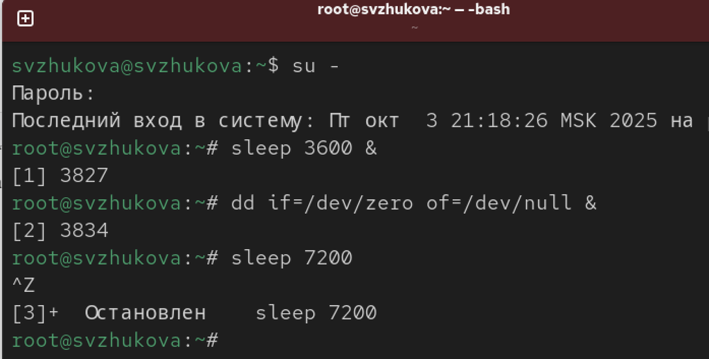

команды

## Введем jobs и увидем три задания, которые мы только что запустили.

Первые два имеют состояние Running, а последнее задание в настоящее время находится в состоянии Stopped

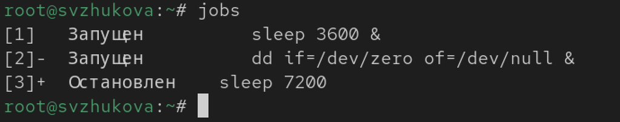

jobs

## Для продолжения выполнения задания 3 в фоновом режиме введем команду

С помощью команды jobs посмотрим изменения в статусе заданий.

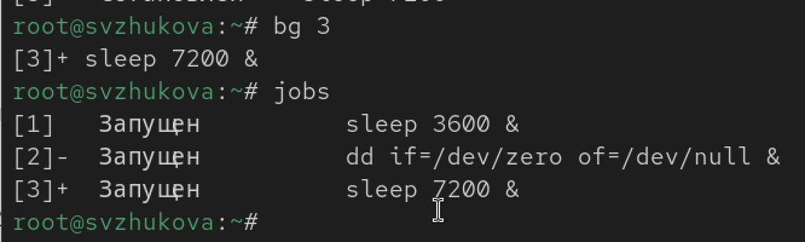

Выполнения задания 3 в фоновом режиме

## Для перемещения задания 1 на передний план введем команду, введем Ctrl + c

чтобы отменить задание 1. С помощью команды jobs посмотрим изменения в статусе заданий.

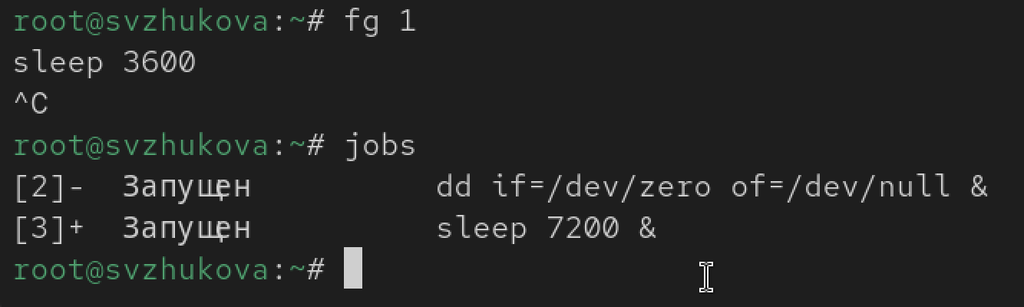

Перемещение задания 1 на передний план

## Проделаем то же самое для отмены заданий 2 и 3.

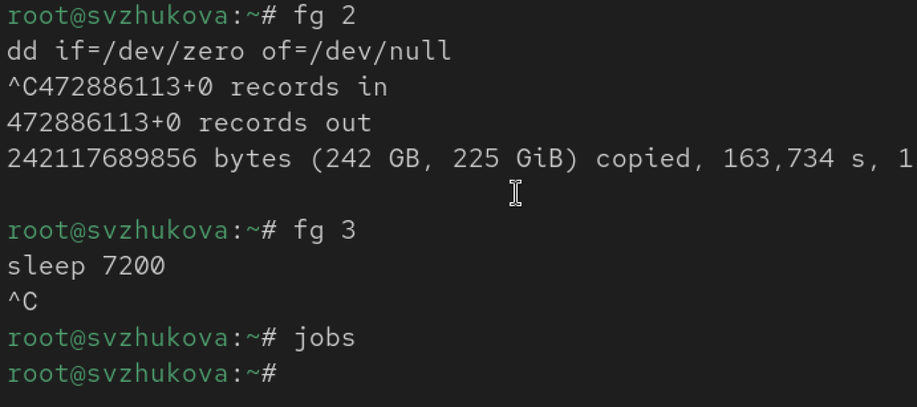

Отмена заданий 2 и 3

## Откроем второй терминал и под учётной записью своего пользователя введем команду, введем exit, чтобы закрыть второй терминал

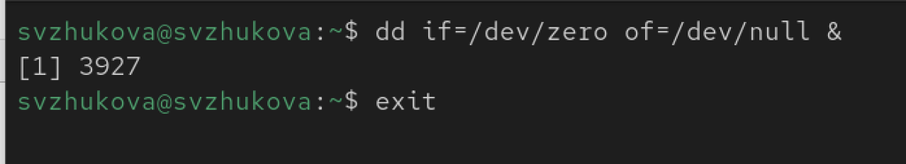

Введем

## а другом терминале под учётной записью своего пользователя запустим top

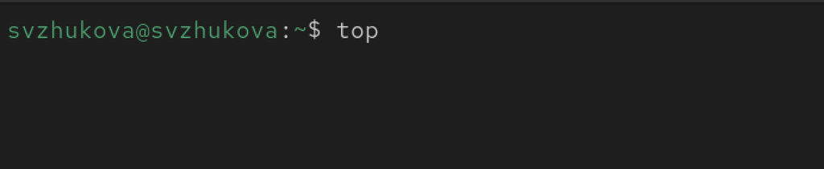

Запустим top

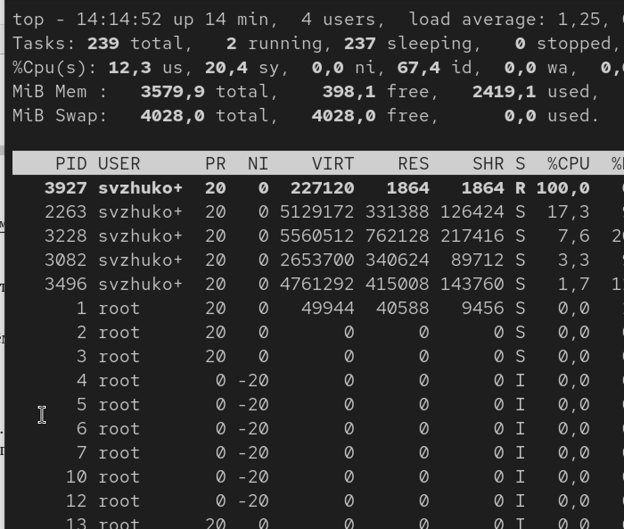

Задание dd всё ещё запущено

## k

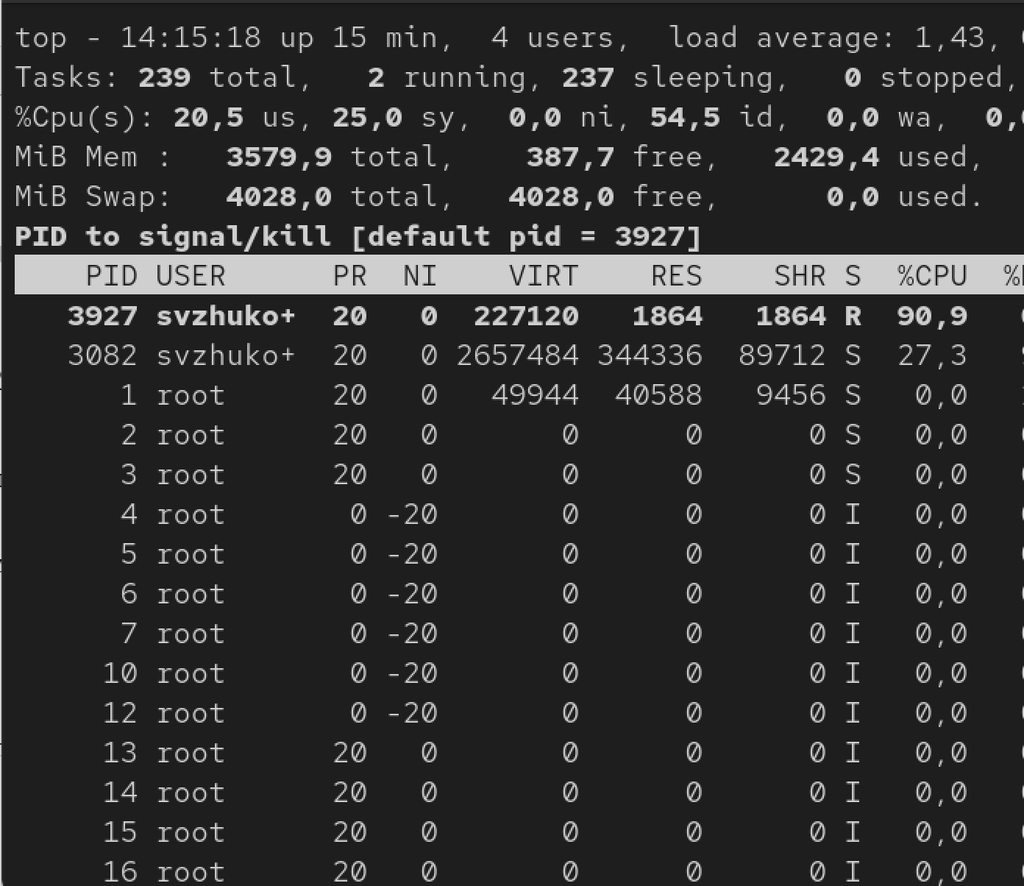

k

## Управление процессами

Получим полномочия администратораъ и введем следующие команды

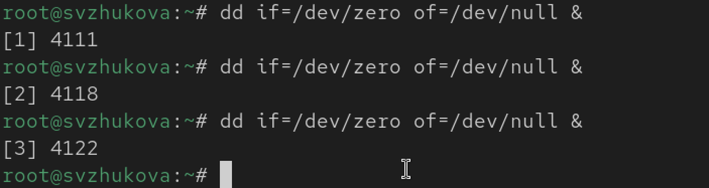

Введем

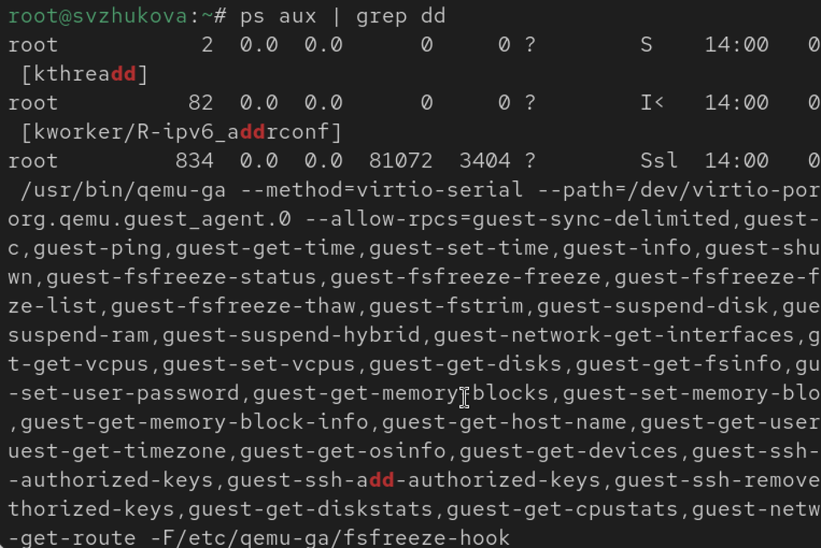

Все строки, в которых есть буквы dd

## Используем PID одного из процессов dd, чтобы изменить приоритет

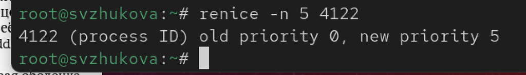

Меняем приоритет

## Введем команду.

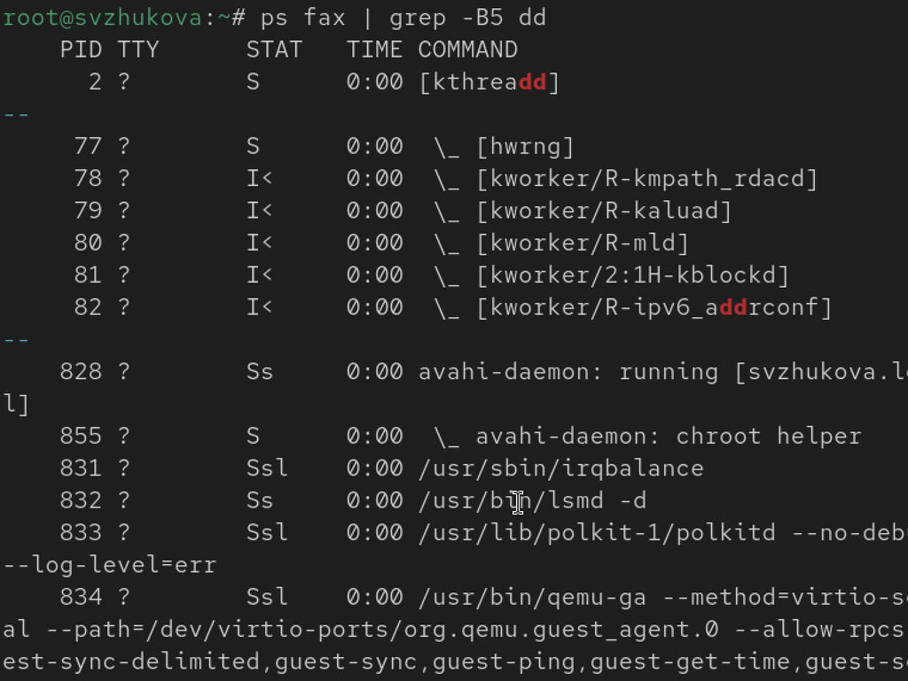

-B5

## Найдем PID корневой оболочки, из которой были запущены процессы dd, и введем kill -9

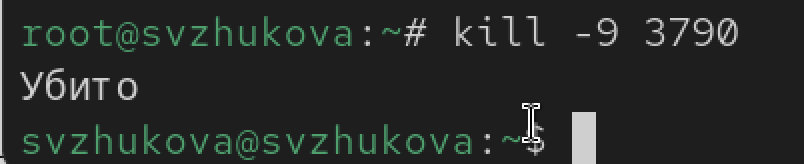

Остановка родительского процесса

## Самостоятельная работа

**Задание 1**

Запустим команду трижды как фоновое задание.

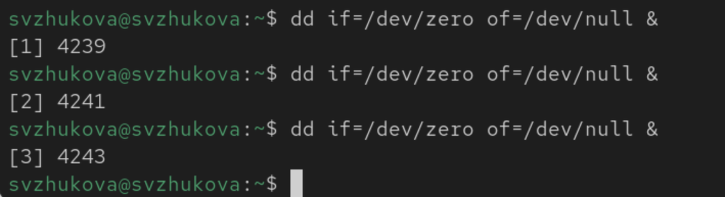

Фоновое задание

## Увеличим приоритет одной из этих команд, используя значение приоритета −5. Изменим приоритет того же процесса ещё раз, но используем на этот раз значение −15

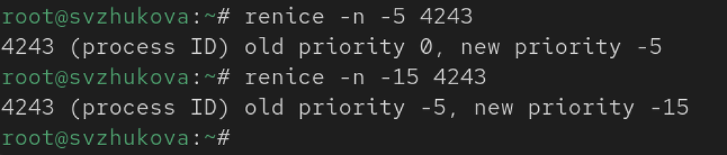

Увеличим приоритет

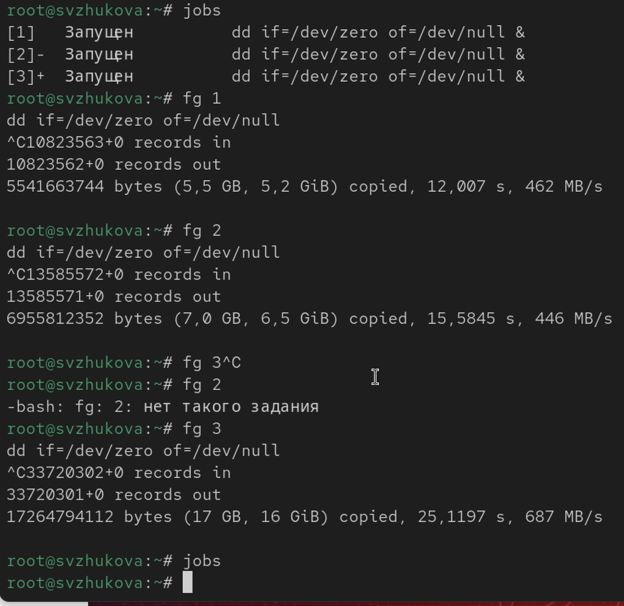

Завершим

## Задание 2

Запустим программу yes в фоновом режиме с подавлением потока вывода. Запустим программу yes на переднем плане с подавлением потока вывода. Приостановим выполнение программы. Заново запустим программу yes с теми же параметрами, затем завершим её выполнение.

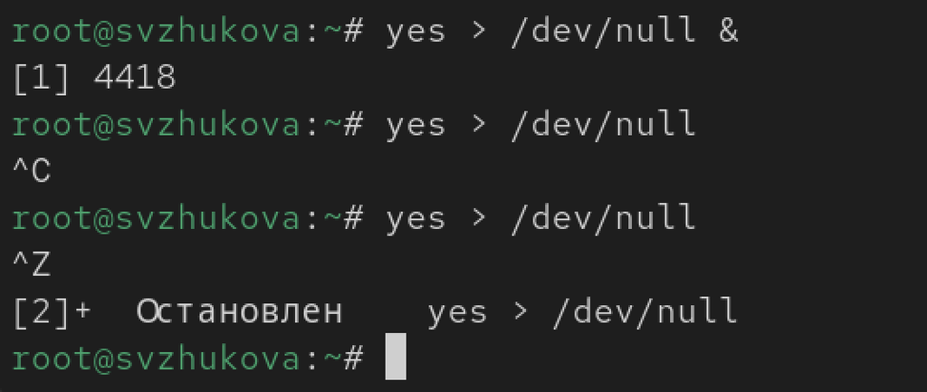

yes

## Запустим программу yes на переднем плане без подавления потока вывода.

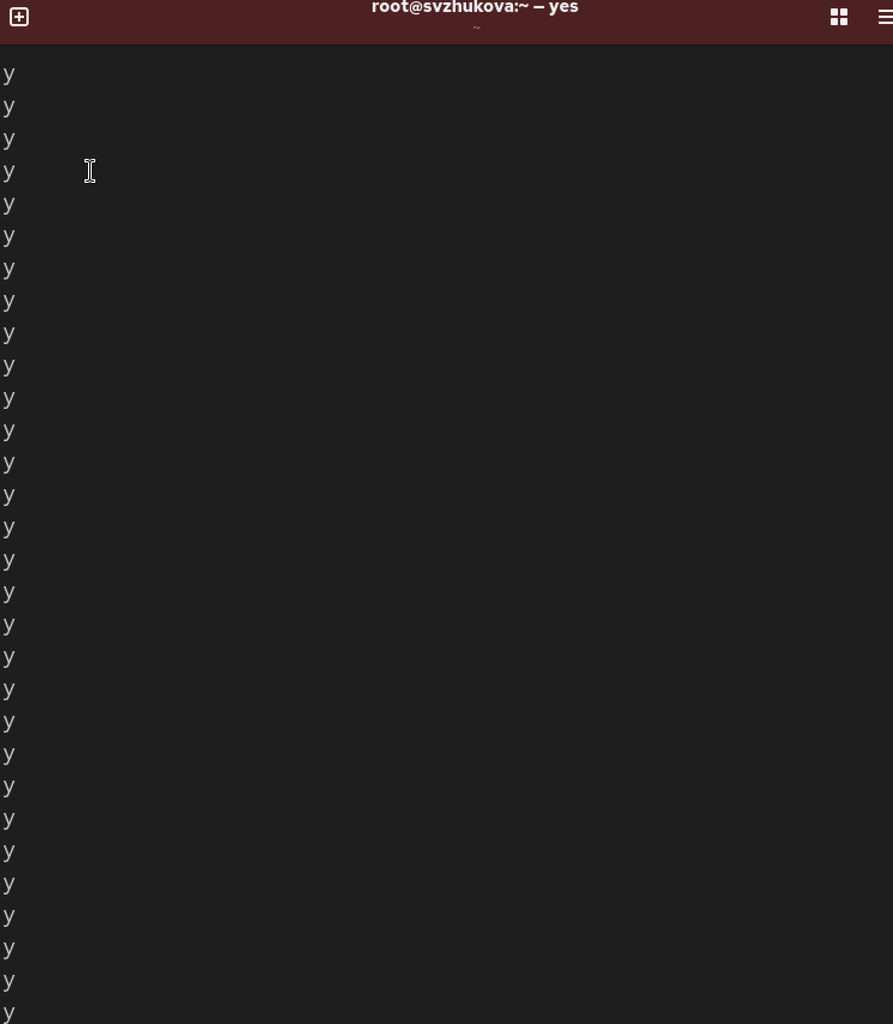

Запустим

## Приостановим выполнение программы.

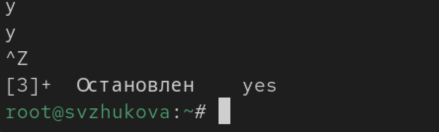

Приостановим

## Заново запустим программу yes с теми же параметрами, затем завершим её выполнение

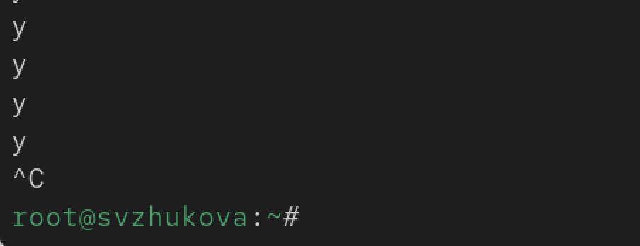

Завершим

## Проверим состояния заданий, воспользовавшись командой, переведем процесс, который у нас выполняется в фоновом режиме, на передний план, затем остановим его

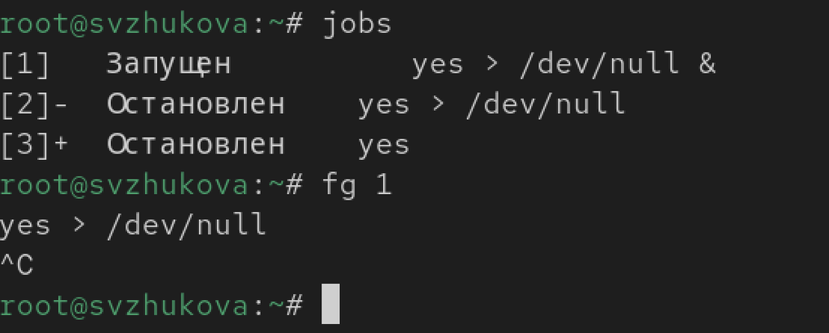

jobs

## Переведем любой ваш процесс с подавлением потока вывода в фоновый режим.

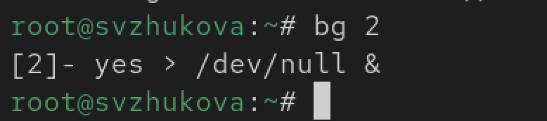

Фоновый режим

## Проверим состояния заданий, воспользовавшись командой jobs. Обратим внимание, что процесс стал выполняющимся (Running) в фоновом режиме

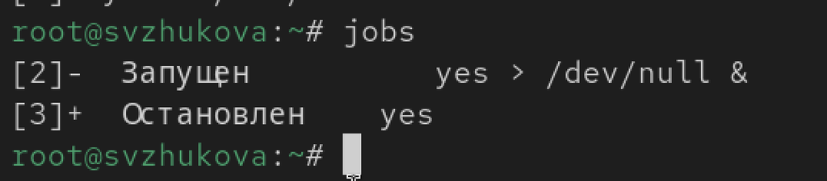

Проверим состояния заданий

## Запустим процесс в фоновом режиме таким образом, чтобы он продолжил свою работу даже после отключения от терминала. Закроем окно и заново запустим консоль. Убедимся, что процесс продолжил свою работу.

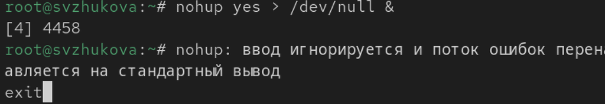

Запустим процесс в фоновом режиме

## Получим информацию о запущенных в операционной системе процессах с помощью утилиты top

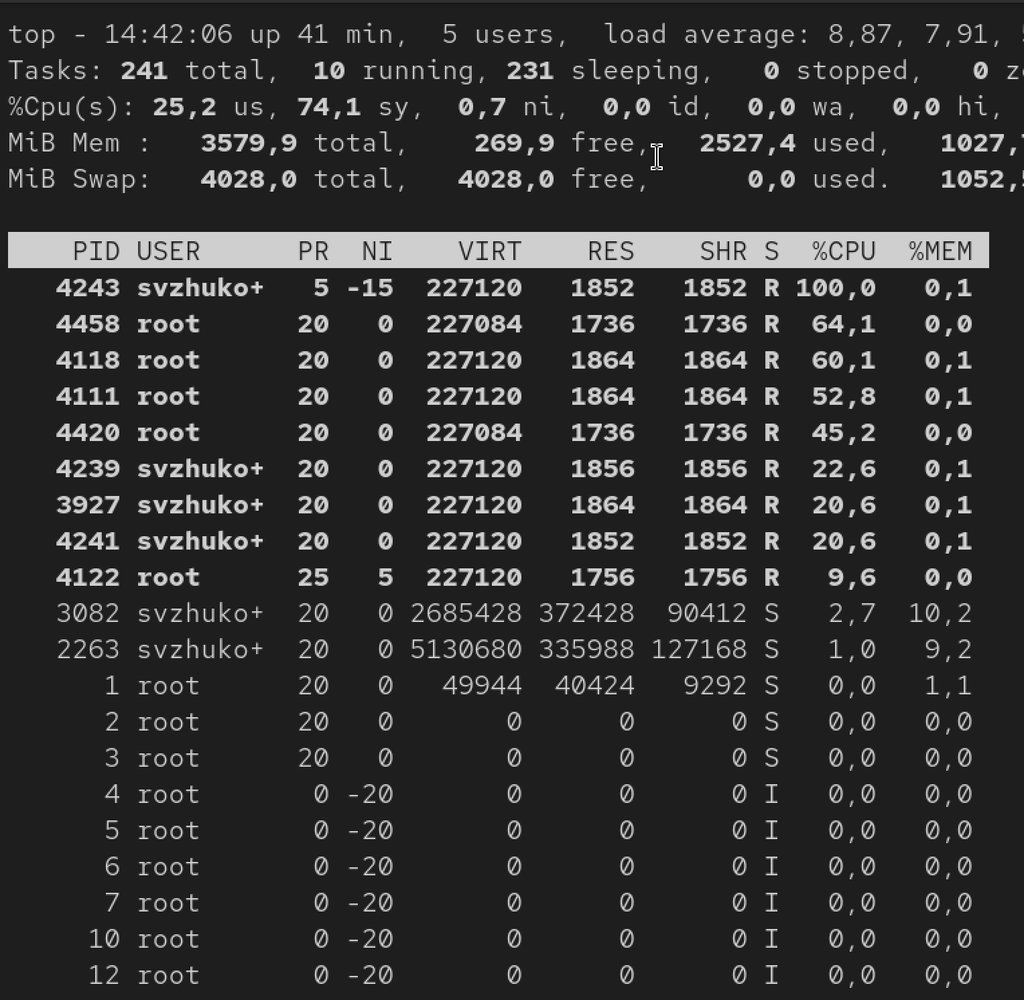

Получим информацию о запущенных в операционной системе процессах

## Запустим ещё три программы yes в фоновом режиме с подавлением потока вывода.

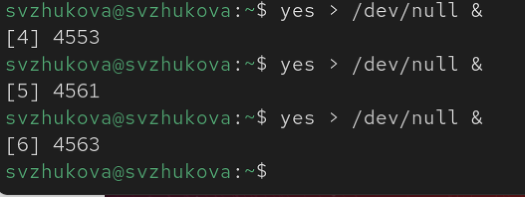

Запустим ещё три программы

## Убьем два процесса:

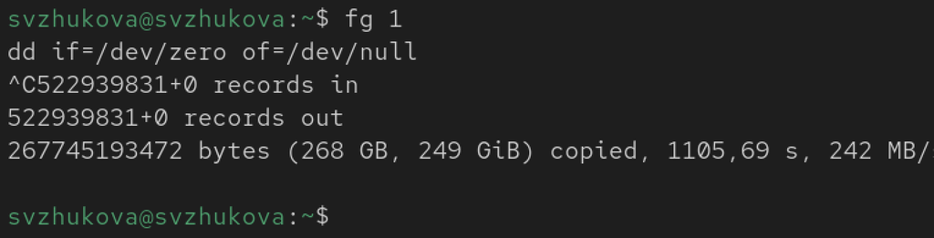

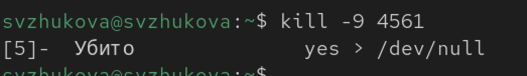

kill

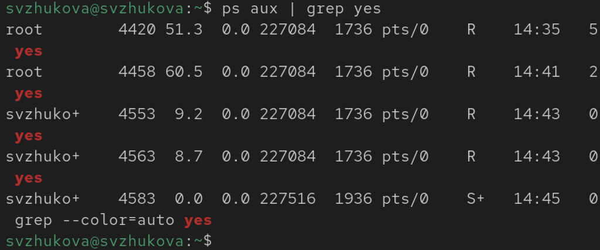

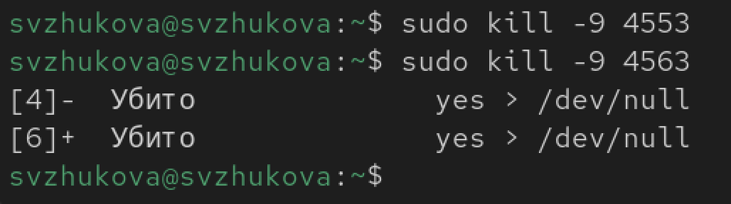